# Housing_Feature_Engg_Loop_LeafNode_decision_Linear_Random_XGBoost_Lisso_Ridge

```python
import numpy as np
import matplotlib.pyplot as plot
import pandas as pd
from sklearn.model_selection import train_test_split
from sklearn.linear_model import LinearRegression
from sklearn.preprocessing import LabelEncoder
import seaborn as sns
from numpy import loadtxt
import xgboost
import math
from sklearn.metrics import accuracy_score
from sklearn.metrics import explained_variance_score
from sklearn.metrics import mean_absolute_error
from sklearn.metrics import r2_score
from sklearn.metrics import mean_squared_error
from math import sqrt
from sklearn import metrics
```

```python
## Read the housing.csv file
data = pd.read_csv("housing.csv")
```

```python
## printed few rows from the housing file
data.head()
```

|  | longitude | latitude | housing_median_age | total_rooms | total_bedrooms | population | households | median_income | ocean_proximity | median_house_value |
| --- | --- | --- | --- | --- | --- | --- | --- | --- | --- | --- |
| 0 | -122.23 | 37.88 | 41 | 880 | 129.0 | 322 | 126 | 8.3252 | NEAR BAY | 452600 |
| 1 | -122.22 | 37.86 | 21 | 7099 | 1106.0 | 2401 | 1138 | 8.3014 | NEAR BAY | 358500 |
| 2 | -122.24 | 37.85 | 52 | 1467 | 190.0 | 496 | 177 | 7.2574 | NEAR BAY | 352100 |
| 3 | -122.25 | 37.85 | 52 | 1274 | 235.0 | 558 | 219 | 5.6431 | NEAR BAY | 341300 |
| 4 | -122.25 | 37.85 | 52 | 1627 | 280.0 | 565 | 259 | 3.8462 | NEAR BAY | 342200 |

```python
## there are 20640 rows and 10 columns in the dataset
data.shape
```

```
(20640, 10)
```

```python
## in the total_bedrooms we have 207 rows which are null
data.isna().sum()
```

```
longitude               0
latitude                0
housing_median_age      0
total_rooms             0
total_bedrooms        207
population              0
households              0
median_income           0
ocean_proximity         0
median_house_value      0
dtype: int64
```

```python
## handling the null value of total bedroom and filling that with the mean value
df=pd.DataFrame(data)
data = df.fillna(int(df['total_bedrooms'].mean()))
```

```python
## Look into the unique values for ocean_proximity
data['ocean_proximity'].unique()
```

```
array(['NEAR BAY', '<1H OCEAN', 'INLAND', 'NEAR OCEAN', 'ISLAND'],
      dtype=object)
```

```python
## Converted the categorical column (ocean_proximity) in the dataset to numerical data
lb = LabelEncoder()
data['ocean_proximity'] = lb.fit_transform(data['ocean_proximity'])
```

```python
## Calculating the correlation of the data
data.corr()
```

|  | longitude | latitude | housing_median_age | total_rooms | total_bedrooms | population | households | median_income | ocean_proximity | median_house_value |
| --- | --- | --- | --- | --- | --- | --- | --- | --- | --- | --- |
| longitude | 1.000000 | -0.924664 | -0.108197 | 0.044568 | 0.069259 | 0.099773 | 0.055310 | -0.015176 | -0.289779 | -0.045967 |
| latitude | -0.924664 | 1.000000 | 0.011173 | -0.036100 | -0.066657 | -0.108785 | -0.071035 | -0.079809 | 0.200974 | -0.144160 |
| housing_median_age | -0.108197 | 0.011173 | 1.000000 | -0.361262 | -0.318999 | -0.296244 | -0.302916 | -0.119034 | 0.112468 | 0.105623 |
| total_rooms | 0.044568 | -0.036100 | -0.361262 | 1.000000 | 0.927253 | 0.857126 | 0.918484 | 0.198050 | -0.015693 | 0.134153 |
| total_bedrooms | 0.069259 | -0.066657 | -0.318999 | 0.927253 | 1.000000 | 0.873909 | 0.974724 | -0.007681 | -0.014688 | 0.049454 |
| population | 0.099773 | -0.108785 | -0.296244 | 0.857126 | 0.873909 | 1.000000 | 0.907222 | 0.004834 | -0.070282 | -0.024650 |
| households | 0.055310 | -0.071035 | -0.302916 | 0.918484 | 0.974724 | 0.907222 | 1.000000 | 0.013033 | -0.018186 | 0.065843 |
| median_income | -0.015176 | -0.079809 | -0.119034 | 0.198050 | -0.007681 | 0.004834 | 0.013033 | 1.000000 | -0.014957 | 0.688075 |
| ocean_proximity | -0.289779 | 0.200974 | 0.112468 | -0.015693 | -0.014688 | -0.070282 | -0.018186 | -0.014957 | 1.000000 | 0.081750 |
| median_house_value | -0.045967 | -0.144160 | 0.105623 | 0.134153 | 0.049454 | -0.024650 | 0.065843 | 0.688075 | 0.081750 | 1.000000 |

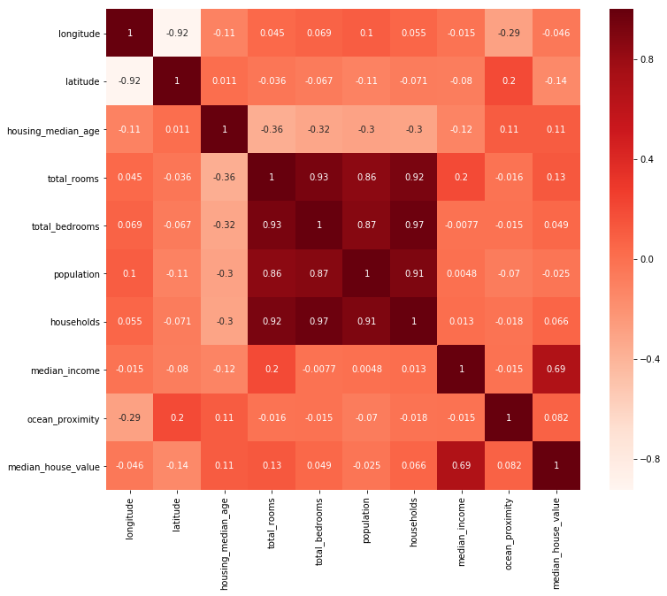

```python
## We can visualize the correlation using the heat map.
plot.figure(figsize=(12,10))
cor = data.corr()
sns.heatmap(cor, annot=True, cmap=plot.cm.Reds)
plot.show()
```

```python
#Correlation with output variable
cor_target = abs(cor["median_house_value"])
#Selecting highly correlated features
relevant_features = cor_target[cor_target>0.5]
print(relevant_features)
```

```
median_income         0.688075
median_house_value    1.000000
Name: median_house_value, dtype: float64
```

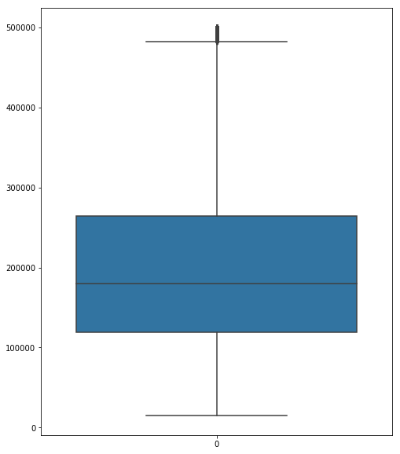

```python
sns.boxplot(data=data['median_house_value'])
```

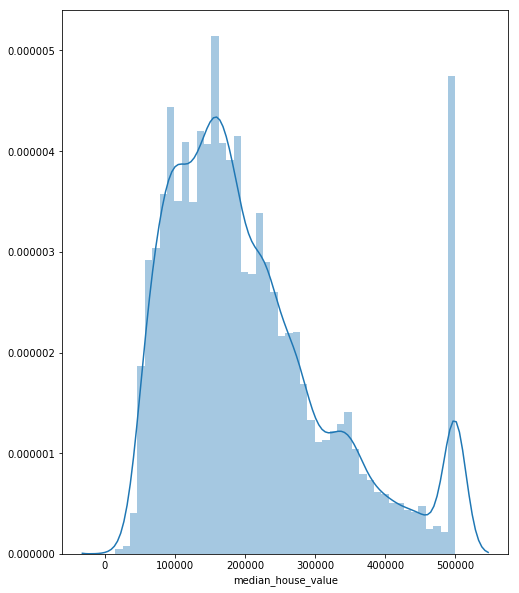

```python
sns.distplot(data['median_house_value'])
```

```python
## WE CAN SEE THAT THERE IS BINOMIAL DISTRIBUTION SO WE ARE ELIMINATING THE MEDIAN_HOUSE_VALUE > 500000

data = data[data['median_house_value'] <= 500000]
```

```python
## We are defining the Dependent and Indepenedent variable and splitting the data into Test and Train
x = data[['longitude','latitude','housing_median_age','total_rooms','total_bedrooms','population','households','median_income','ocean_proximity']]
y = data[['median_house_value']]
x_train, x_test, y_train, y_test =train_test_split(x,y, test_size = 0.20)
```

# Linear Regression

```python
from sklearn.linear_model import LinearRegression
lm = LinearRegression()

### MODELFITSTRAIN - use the LinearRegression() function on my training data
lm.fit(x_train,y_train)
```

```
LinearRegression(copy_X=True, fit_intercept=True, n_jobs=None,
         normalize=False)
```

```python
pred_y = lm.predict(x_test)
```

```python
pred_y_scatter = pd.DataFrame(pred_y).iloc[:,0]
y_test_scatter = pd.DataFrame(y_test).iloc[:,0]
```

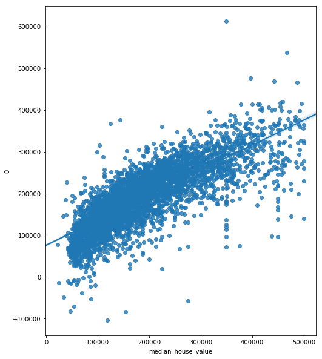

```python
### Visualtion of predictive results, y_test for prediction
sns.regplot(y_test_scatter,pred_y_scatter)
```

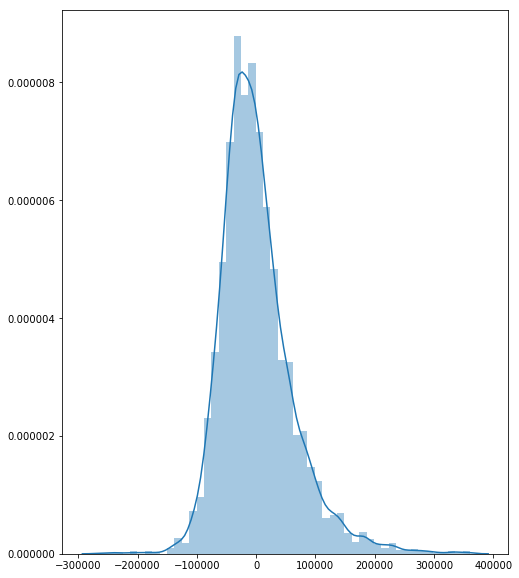

```python
sns.distplot((y_test-pred_y))
```

```python
## calculating the RMSE
rmse_linear = sqrt(mean_squared_error(y_test,pred_y))
print('RMSE : ',rmse_linear)
```

```
RMSE :  61552.42237972317
```

```python
#R Squared calculated.
r2_linear =r2_score(y_test,pred_y)
r2_linear
```

```
0.6113069472584316
```

# XG Boost

```python
# split data into train and test sets
X_train_XG, X_test_XG, y_train_XG, y_test_XG = train_test_split(x, y, test_size=0.15, random_state=7)
```

```python
# Let's try XGboost algorithm to see if we can get better results
xgb = xgboost.XGBRegressor(n_estimators=100, learning_rate=0.40, gamma=0, subsample=0.75,
                           colsample_bytree=1, max_depth=7)
```

```python
xgb.fit(X_train_XG,y_train_XG)
```

```
XGBRegressor(base_score=0.5, booster='gbtree', colsample_bylevel=1,
       colsample_bytree=1, gamma=0, importance_type='gain',
       learning_rate=0.4, max_delta_step=0, max_depth=7,
       min_child_weight=1, missing=None, n_estimators=100, n_jobs=1,
       nthread=None, objective='reg:linear', random_state=0, reg_alpha=0,
       reg_lambda=1, scale_pos_weight=1, seed=None, silent=True,
       subsample=0.75)
```

```python
predictions_XG = xgb.predict(X_test_XG)

## Calculating the RMSE
rmse_XG = sqrt(mean_squared_error(predictions_XG,y_test_XG))
print('RMSE: ',rmse_XG)
```

```
RMSE:  44763.83785395199
```

```python
predictions_scatter_XG = pd.DataFrame(predictions_XG).iloc[:,0]
y_scatter_test_XG = pd.DataFrame(y_test_XG).iloc[:,0]
```

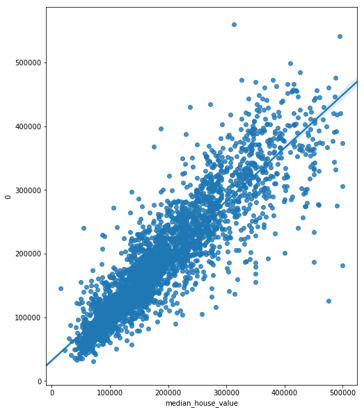

```python
### Visualtion of predictive results, y_test is actual y, pred_y is the predicted
sns.regplot(x=y_scatter_test_XG,y=predictions_scatter_XG)
```

```python
#RSquared calculation
r2_XGBoost = r2_score(predictions_XG,y_test_XG)
r2_XGBoost
```

```
0.7589018215683135
```

# Decision Tree

```python
def get_md(leaf_nodes,depth,X_train_DT, X_test_DT, y_train_DT, y_test_DT):
    model = DecisionTreeRegressor(max_leaf_nodes=leaf_nodes,max_depth=depth,random_state=0)
    model.fit(X_train_DT,y_train_DT)
    a = model.predict(X_test_DT)
    mae = sqrt(mean_squared_error(a,y_test_DT))
    #mae = mean_absolute_error(y_test_DT,a)
    return(mae)
```

```python
from sklearn.tree import DecisionTreeRegressor
from sklearn import tree

X_train_DT, X_test_DT, y_train_DT, y_test_DT = train_test_split(x, y, test_size = 0.2) ##, random_state = 7
regressor = DecisionTreeRegressor(random_state = 0,max_leaf_nodes = 505,max_depth=9)
regressor.fit(X_train_DT, y_train_DT)
```

```
DecisionTreeRegressor(criterion='mse', max_depth=9, max_features=None,
           max_leaf_nodes=505, min_impurity_decrease=0.0,
           min_impurity_split=None, min_samples_leaf=1,
           min_samples_split=2, min_weight_fraction_leaf=0.0,
           presort=False, random_state=0, splitter='best')
```

```python
for leaf_nodes in np.arange(5,5000,500):
    for depth in np.arange(1,10):
        mae = get_md(leaf_nodes,depth,X_train_DT, X_test_DT, y_train_DT, y_test_DT)
        print('leaf nodes',leaf_nodes,"  >>>>>>>>>>  ",'depth',depth,"  >>>>>>>>>>  ",mae)
```

```
leaf nodes 5   >>>>>>>>>>   depth 1   >>>>>>>>>>   77270.40328678697
leaf nodes 5   >>>>>>>>>>   depth 2   >>>>>>>>>>   76139.0541600668
leaf nodes 5   >>>>>>>>>>   depth 3   >>>>>>>>>>   76139.0541600668
leaf nodes 5   >>>>>>>>>>   depth 4   >>>>>>>>>>   76139.0541600668
leaf nodes 5   >>>>>>>>>>   depth 5   >>>>>>>>>>   76139.0541600668
leaf nodes 5   >>>>>>>>>>   depth 6   >>>>>>>>>>   76139.0541600668
leaf nodes 5   >>>>>>>>>>   depth 7   >>>>>>>>>>   76139.0541600668
leaf nodes 5   >>>>>>>>>>   depth 8   >>>>>>>>>>   76139.0541600668
leaf nodes 5   >>>>>>>>>>   depth 9   >>>>>>>>>>   76139.0541600668
leaf nodes 505   >>>>>>>>>>   depth 1   >>>>>>>>>>   77270.40328678697
leaf nodes 505   >>>>>>>>>>   depth 2   >>>>>>>>>>   73469.01791783645
leaf nodes 505   >>>>>>>>>>   depth 3   >>>>>>>>>>   66877.04644769427
leaf nodes 505   >>>>>>>>>>   depth 4   >>>>>>>>>>   62160.06077050876
leaf nodes 505   >>>>>>>>>>   depth 5   >>>>>>>>>>   58996.63364161403
leaf nodes 505   >>>>>>>>>>   depth 6   >>>>>>>>>>   56032.014059265864
leaf nodes 505   >>>>>>>>>>   depth 7   >>>>>>>>>>   54231.16118476264
leaf nodes 505   >>>>>>>>>>   depth 8   >>>>>>>>>>   53195.421968622795
leaf nodes 505   >>>>>>>>>>   depth 9   >>>>>>>>>>   52944.59249291282
leaf nodes 1005   >>>>>>>>>>   depth 1   >>>>>>>>>>   77270.40328678697
leaf nodes 1005   >>>>>>>>>>   depth 2   >>>>>>>>>>   73469.01791783645
leaf nodes 1005   >>>>>>>>>>   depth 3   >>>>>>>>>>   66877.04644769427
leaf nodes 1005   >>>>>>>>>>   depth 4   >>>>>>>>>>   62160.06077050876
leaf nodes 1005   >>>>>>>>>>   depth 5   >>>>>>>>>>   58996.63364161403
leaf nodes 1005   >>>>>>>>>>   depth 6   >>>>>>>>>>   56032.014059265864
leaf nodes 1005   >>>>>>>>>>   depth 7   >>>>>>>>>>   54231.16118476264
leaf nodes 1005   >>>>>>>>>>   depth 8   >>>>>>>>>>   53195.421968622795
leaf nodes 1005   >>>>>>>>>>   depth 9   >>>>>>>>>>   53161.90307828941
leaf nodes 1505   >>>>>>>>>>   depth 1   >>>>>>>>>>   77270.40328678697
leaf nodes 1505   >>>>>>>>>>   depth 2   >>>>>>>>>>   73469.01791783645
leaf nodes 1505   >>>>>>>>>>   depth 3   >>>>>>>>>>   66877.04644769427
leaf nodes 1505   >>>>>>>>>>   depth 4   >>>>>>>>>>   62160.06077050876
leaf nodes 1505   >>>>>>>>>>   depth 5   >>>>>>>>>>   58996.63364161403
leaf nodes 1505   >>>>>>>>>>   depth 6   >>>>>>>>>>   56032.014059265864
leaf nodes 1505   >>>>>>>>>>   depth 7   >>>>>>>>>>   54231.16118476264
leaf nodes 1505   >>>>>>>>>>   depth 8   >>>>>>>>>>   53195.421968622795
leaf nodes 1505   >>>>>>>>>>   depth 9   >>>>>>>>>>   53161.90307828941
leaf nodes 2005   >>>>>>>>>>   depth 1   >>>>>>>>>>   77270.40328678697
leaf nodes 2005   >>>>>>>>>>   depth 2   >>>>>>>>>>   73469.01791783645
leaf nodes 2005   >>>>>>>>>>   depth 3   >>>>>>>>>>   66877.04644769427
leaf nodes 2005   >>>>>>>>>>   depth 4   >>>>>>>>>>   62160.06077050876
```

[output cut: 35 more lines]

```
leaf nodes 4005   >>>>>>>>>>   depth 4   >>>>>>>>>>   62160.06077050876
leaf nodes 4005   >>>>>>>>>>   depth 5   >>>>>>>>>>   58996.63364161403
leaf nodes 4005   >>>>>>>>>>   depth 6   >>>>>>>>>>   56032.014059265864
leaf nodes 4005   >>>>>>>>>>   depth 7   >>>>>>>>>>   54231.16118476264
leaf nodes 4005   >>>>>>>>>>   depth 8   >>>>>>>>>>   53195.421968622795
leaf nodes 4005   >>>>>>>>>>   depth 9   >>>>>>>>>>   53161.90307828941
leaf nodes 4505   >>>>>>>>>>   depth 1   >>>>>>>>>>   77270.40328678697
leaf nodes 4505   >>>>>>>>>>   depth 2   >>>>>>>>>>   73469.01791783645
leaf nodes 4505   >>>>>>>>>>   depth 3   >>>>>>>>>>   66877.04644769427
leaf nodes 4505   >>>>>>>>>>   depth 4   >>>>>>>>>>   62160.06077050876
leaf nodes 4505   >>>>>>>>>>   depth 5   >>>>>>>>>>   58996.63364161403
leaf nodes 4505   >>>>>>>>>>   depth 6   >>>>>>>>>>   56032.014059265864
leaf nodes 4505   >>>>>>>>>>   depth 7   >>>>>>>>>>   54231.16118476264
leaf nodes 4505   >>>>>>>>>>   depth 8   >>>>>>>>>>   53195.421968622795
leaf nodes 4505   >>>>>>>>>>   depth 9   >>>>>>>>>>   53161.90307828941
```

```python
y_pred_DT = regressor.predict(X_test_DT)
y_pred_DT
```

```
array([203673.077, 195829.588, 165206.767, ..., 117412.245, 199143.404,
       319285.714])
```

```python
y_scatter_pred_DT = pd.DataFrame(y_pred_DT).iloc[:,0]
y_scatter_test_DT = pd.DataFrame(y_test_DT).iloc[:,0]
```

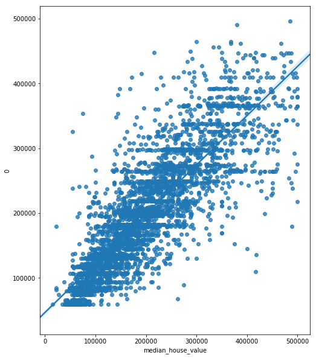

```python
### Visualtion of predictive results, y_test is actual y, pred_y is the predicted
sns.regplot(y_scatter_test_DT,y_scatter_pred_DT)
```

```python
## Calculate the RMSE
rmse_DT = sqrt(mean_squared_error(y_pred_DT,y_test_DT))
print('RMSE: ',rmse_DT)
```

```
RMSE:  52944.59249291282
```

```python
##RSquared calculation
R2_DT = r2_score(y_pred_DT,y_test_DT)
R2_DT
```

```
0.6427863449845572
```

# Random Forest

```python
# Using Skicit-learn to split data into training and testing sets
from sklearn.model_selection import train_test_split
# Split the data into training and testing sets
train_features, test_features, train_labels, test_labels = train_test_split(x, y, test_size = 0.20, random_state = 7)

# Import the model we are using
from sklearn.ensemble import RandomForestRegressor
# Instantiate model with 1000 decision trees
rf = RandomForestRegressor(n_estimators = 120, random_state = 0)
# Train the model on training data
rf.fit(train_features, train_labels);
```

```python
# Use the forest's predict method on the test data
predictions = rf.predict(test_features)
```

```python
rmse_RF = sqrt(mean_squared_error(predictions,test_labels))
print('RMSE :',rmse_RF)
```

```
RMSE : 43133.26190115921
```

```python
## Calculating the RMSE
print('Root Mean Squared Error:', np.sqrt(metrics.mean_squared_error(test_labels, predictions)))
```

```
Root Mean Squared Error: 43133.26190115921
```

```python
predictions_scatter_RF = pd.DataFrame(predictions).iloc[:,0]
test_labels_scatter_RF = pd.DataFrame(test_labels).iloc[:,0]
```

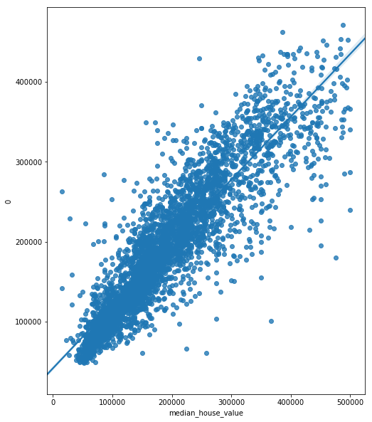

```python
### Visualtion of predictive results, y_test is actual y, pred_y is the predicted
sns.regplot(test_labels_scatter_RF,predictions_scatter_RF)
```

```python
#RSquared calculation
r2_RF = r2_score(test_labels, predictions)
r2_RF
```

```
0.8031982841279852
```

# Linear Regression with median Income

```python
# will take only median_income as an variable
X = data[['median_income']]
Y = data[['median_house_value']]
X_train, X_test, Y_train, Y_test =train_test_split(X,Y, test_size = 0.20)
```

```python
from sklearn.linear_model import LinearRegression
lm = LinearRegression()

### use the LinearRegression() function on my training data
lm.fit(X_train,Y_train)
```

```
LinearRegression(copy_X=True, fit_intercept=True, n_jobs=None,
         normalize=False)
```

```python
pred_Y = lm.predict(X_test)
```

```python
#pred_y_scatter = list(pred_y)
#y_test_scatter =list(y_test['median_house_value'])
pred_Y_scatter = pd.DataFrame(pred_Y).iloc[:,0]
Y_test_scatter = pd.DataFrame(Y_test).iloc[:,0]
```

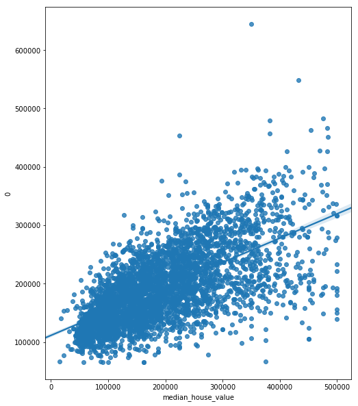

```python
### Visualtion of predictive results, y_test is actual y, pred_y is the predicted
sns.regplot(Y_test_scatter,pred_Y_scatter)
```

```python
## Calculate the RMSE
RMSE = sqrt(mean_squared_error(Y_test,pred_Y))
print('RMSE: ',RMSE)
```

```
RMSE:  74597.7565370354
```

```python
#RSquared calculation
r2_score(Y_test,pred_Y)
```

```
0.4182640237655404
```

# XG BOOST with median Income

```python
# split data into train and test sets
x_train_XG, x_test_XG, Y_train_XG, Y_test_XG = train_test_split(X, Y, test_size=0.20, random_state=7)
```

```python
# Let's try XGboost algorithm to see if we can get better results
xgb = xgboost.XGBRegressor(n_estimators=100, learning_rate=0.25, gamma=0, subsample=0.75,
                           colsample_bytree=1, max_depth=7)
```

```python
xgb.fit(x_train_XG,Y_train_XG)
```

```
XGBRegressor(base_score=0.5, booster='gbtree', colsample_bylevel=1,
       colsample_bytree=1, gamma=0, importance_type='gain',
       learning_rate=0.25, max_delta_step=0, max_depth=7,
       min_child_weight=1, missing=None, n_estimators=100, n_jobs=1,
       nthread=None, objective='reg:linear', random_state=0, reg_alpha=0,
       reg_lambda=1, scale_pos_weight=1, seed=None, silent=True,
       subsample=0.75)
```

```python
Predictions_XG = xgb.predict(x_test_XG)
RMSE_XG = sqrt(mean_squared_error(Predictions_XG,Y_test_XG))
print('RMSE: ',RMSE_XG)
```

```
RMSE:  75945.03049786662
```

```python
#pred_y_scatter = list(pred_y)
#y_test_scatter =list(y_test['median_house_value'])
Predictions_scatter_XG = pd.DataFrame(Predictions_XG).iloc[:,0]
Y_scatter_test_XG = pd.DataFrame(Y_test_XG).iloc[:,0]
```

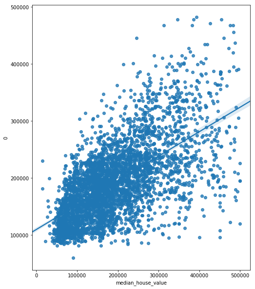

```python
### Visualtion of predictive results, y_test is actual y, pred_y is the predicted
sns.regplot(Y_scatter_test_XG,Predictions_scatter_XG)
```

```python
#RSquared calculation
r2_score(Y_scatter_test_XG,Predictions_scatter_XG)
```

```
0.3898972289301923
```

# Comparing RMSE and R Squared for all models

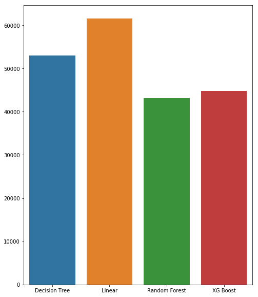

```python
## Calculation of RMSE and compare with all the model that we have implemented.
rmse_compare = [{'Linear':rmse_linear,'Decision Tree':rmse_DT,'Random Forest':rmse_RF,'XG Boost':rmse_XG}]
rmse_compare = pd.DataFrame(rmse_compare)
sns.barplot(data=rmse_compare)
```

From the above graph we can predict that the Random Forest and XG Boost algorithm gives us the least 'Sqrt Root mean square'

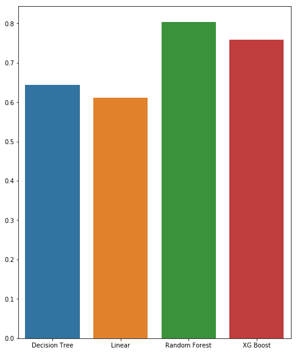

```python
## Calculation of R Squared and compare with all the model that we have implemented.
rsquared_compare = [{'Linear':r2_linear,'Decision Tree':R2_DT,'Random Forest':r2_RF,'XG Boost':r2_XGBoost}]
rsquared_compare = pd.DataFrame(rsquared_compare)
sns.barplot(data=rsquared_compare)
```

From the above graph we can predict that the Random Forest and XG Boost algorithm gives us the high R Squared value

## We can do the feature engineering on the above model as there is lot of scope of improvement.

## 1) SelectKBest

```python
from sklearn.feature_selection import SelectKBest
from sklearn.feature_selection import chi2
test = SelectKBest(score_func= chi2, k=4)
```

```python
x_f = data[['longitude','latitude','housing_median_age','total_rooms','total_bedrooms','population','households','median_income','ocean_proximity']]
y_f = data[['median_house_value']]
x_f['longitude_abs'] = x_f['longitude'].abs()
x_f=x_f.reindex(columns=['longitude_abs','latitude','housing_median_age','total_rooms','total_bedrooms','population','households','median_income','ocean_proximity'])
fit = test.fit(x_f,y_f)
```

```python
np.set_printoptions(precision=3)
print(fit.scores_)
```

```
[1.347e+02 5.859e+02 2.245e+04 9.791e+06 1.396e+06 3.877e+06 1.297e+06
 8.030e+03 7.874e+03]
```

```python
features = fit.transform(x_f)
# summarize selected features
print(features[0:,:])
```

```
[[ 880.  129.  322.  126.]
 [7099. 1106. 2401. 1138.]
 [1467.  190.  496.  177.]
 ...
 [2254.  485. 1007.  433.]
 [1860.  409.  741.  349.]
 [2785.  616. 1387.  530.]]
```

```python
# Using Skicit-learn to split data into training and testing sets

x_f_skb = x_f[['total_rooms','total_bedrooms','population','households']]
y_f_skb = y_f[['median_house_value']]

from sklearn.model_selection import train_test_split
# Split the data into training and testing sets
train_features, test_features, train_labels, test_labels = train_test_split(x_f_skb, y_f_skb, test_size = 0.30, random_state = 7)

# Import the model we are using
from sklearn.ensemble import RandomForestRegressor
# Instantiate model with 1000 decision trees
rf = RandomForestRegressor(n_estimators = 120, random_state = 0)
# Train the model on training data
rf.fit(train_features, train_labels);

# Use the forest's predict method on the test data
predictions = rf.predict(test_features)

#RSquared calculation
r2_RF = r2_score(test_labels, predictions)
r2_RF
```

```
0.21252558449318548
```

From the above SelectKBest am getting 'total_rooms','total_bedrooms','population','households' as 4 best feature but we are not getting the expected R Squared. So we can't take the SelectKBest features.

## 2) RFE

```python
from sklearn.feature_selection import RFE
model = RandomForestRegressor()
rfe = RFE(model, 4)
fit = rfe.fit(x, y)
print("Num Features: %d" % fit.n_features_)
print("Selected Features: %s" % fit.support_)
print("Feature Ranking: %s" % fit.ranking_)
```

```
Num Features: 4
Selected Features: [ True  True False False False False False  True  True]
Feature Ranking: [1 1 2 3 5 4 6 1 1]
```

##['longitude_abs','latitude','housing_median_age','total_rooms','total_bedrooms','population','households','median_income','ocean_proximity'] ## from the above RME we can find that the 'longitude_abs','latitude','median_income','ocean_proximity'

```python
# Using Skicit-learn to split data into training and testing sets

x_f_skb = x_f[['longitude_abs','latitude','population','households','housing_median_age']]
y_f_skb = y_f[['median_house_value']]

from sklearn.model_selection import train_test_split
# Split the data into training and testing sets
train_features, test_features, train_labels, test_labels = train_test_split(x_f_skb, y_f_skb, test_size = 0.30, random_state = 7)

# Import the model we are using
from sklearn.ensemble import RandomForestRegressor
# Instantiate model with 1000 decision trees
rf = RandomForestRegressor(n_estimators = 120, random_state = 0)
# Train the model on training data
rf.fit(train_features, train_labels);

# Use the forest's predict method on the test data
predictions = rf.predict(test_features)

#RSquared calculation
r2_RF = r2_score(test_labels, predictions)
r2_RF
```

```
0.7533276733291334
```

## Backward Elimination OLS Method

```python
import statsmodels.api as sm
#Adding constant column of ones, mandatory for sm.OLS model
X_1 = sm.add_constant(x_f)
#Fitting sm.OLS model
model = sm.OLS(y_f,X_1).fit()
model.pvalues
```

```
const                  0.000000e+00
longitude_abs          0.000000e+00
latitude               0.000000e+00
housing_median_age    1.128377e-133
total_rooms            2.506043e-28
total_bedrooms         1.667500e-44
population            3.791099e-228
households             1.414917e-29
median_income          0.000000e+00
ocean_proximity        6.137217e-01
dtype: float64
```

```python
#Backward Elimination
cols = list(x_f.columns)
pmax = 1
while (len(cols)>0):
    p= []
    X_1 = x_f[cols]
    X_1 = sm.add_constant(X_1)
    model = sm.OLS(y_f,X_1).fit()
    p = pd.Series(model.pvalues.values[1:],index = cols)
    pmax = max(p)
    feature_with_p_max = p.idxmax()
    if(pmax>0.05):
        cols.remove(feature_with_p_max)
    else:
        break
selected_features_BE = cols
print(selected_features_BE)
```

```
['longitude_abs', 'latitude', 'housing_median_age', 'total_rooms', 'total_bedrooms', 'population', 'households', 'median_income']
```

```python
# Using Skicit-learn to split data into training and testing sets

x_f_skb = x_f[['longitude_abs', 'latitude', 'housing_median_age', 'total_rooms', 'total_bedrooms', 'population', 'households', 'median_income']]
y_f_skb = y_f[['median_house_value']]

from sklearn.model_selection import train_test_split
# Split the data into training and testing sets
train_features, test_features, train_labels, test_labels = train_test_split(x_f_skb, y_f_skb, test_size = 0.30, random_state = 7)

# Import the model we are using
from sklearn.ensemble import RandomForestRegressor
# Instantiate model with 1000 decision trees
rf = RandomForestRegressor(n_estimators = 120, random_state = 0)
# Train the model on training data
rf.fit(train_features, train_labels);

# Use the forest's predict method on the test data
predictions = rf.predict(test_features)

#RSquared calculation
r2_RF = r2_score(test_labels, predictions)
r2_RF
```

```
0.7946645343229846
```

## So via OLS we have eliminated ocean_proximity and getting good R2 value

## Embedded Method

```python
from sklearn.linear_model import RidgeCV, LassoCV, Ridge, Lasso
reg = LassoCV()
reg.fit(x_f, y_f)
print("Best alpha using built-in LassoCV: %f" % reg.alpha_)
print("Best score using built-in LassoCV: %f" %reg.score(x_f,y_f))
coef = pd.Series(reg.coef_, index = x_f.columns)
```

```
Best alpha using built-in LassoCV: 30507.441572
Best score using built-in LassoCV: 0.454767
```

```python
coef
```

```
longitude_abs             0.000000
latitude                 -0.000000
housing_median_age     1274.379019
total_rooms              -0.452977
total_bedrooms          -25.543803
population              -35.474934
households              157.221721
median_income         29207.960358
ocean_proximity           0.000000
dtype: float64
```

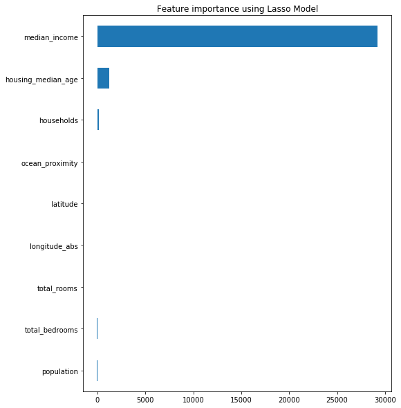

```python
imp_coef = coef.sort_values()
import matplotlib
matplotlib.rcParams['figure.figsize'] = (8.0, 10.0)
imp_coef.plot(kind = "barh")
plot.title("Feature importance using Lasso Model")
```

```python
## using the Lasso it says that we have to remove Ocean Proximity, Latitude, Longitude_abs total_rooms so lets check after removing how much we are getting the RSquared.
```

```python
# Using Skicit-learn to split data into training and testing sets

x_f_skb = x_f[['housing_median_age', 'total_bedrooms', 'population', 'households', 'median_income', 'total_rooms']]
y_f_skb = y_f[['median_house_value']]

from sklearn.model_selection import train_test_split
# Split the data into training and testing sets
train_features, test_features, train_labels, test_labels = train_test_split(x_f_skb, y_f_skb, test_size = 0.30, random_state = 7)

# Import the model we are using
from sklearn.ensemble import RandomForestRegressor
# Instantiate model with 1000 decision trees
rf = RandomForestRegressor(n_estimators = 120, random_state = 0)
# Train the model on training data
rf.fit(train_features, train_labels);

# Use the forest's predict method on the test data
predictions = rf.predict(test_features)

#RSquared calculation
r2_RF = r2_score(test_labels, predictions)
r2_RF
```

```
0.6001400404213433
```

## so after the lasso we can see that the R Squared is 60...So after the analysis we found out that we can consider OLS method for feature engineering.## Also lets check do we have any multicollinearity in the selected feature.

```python
data_mc = data[['longitude','latitude','housing_median_age','total_rooms','total_bedrooms','population',
               'households','median_income','median_house_value']]
```

```python
data_mc.corr()
```

|  | longitude | latitude | housing_median_age | total_rooms | total_bedrooms | population | households | median_income | median_house_value |
| --- | --- | --- | --- | --- | --- | --- | --- | --- | --- |
| longitude | 1.000000 | -0.924139 | -0.102504 | 0.044304 | 0.069516 | 0.101061 | 0.055726 | -0.009067 | -0.046658 |
| latitude | -0.924139 | 1.000000 | 0.006633 | -0.033417 | -0.067603 | -0.113378 | -0.072820 | -0.078026 | -0.148289 |
| housing_median_age | -0.102504 | 0.006633 | 1.000000 | -0.372009 | -0.325807 | -0.295124 | -0.309438 | -0.194784 | 0.067948 |
| total_rooms | 0.044304 | -0.033417 | -0.372009 | 1.000000 | 0.930918 | 0.859590 | 0.921102 | 0.224207 | 0.143139 |
| total_bedrooms | 0.069516 | -0.067603 | -0.325807 | 0.930918 | 1.000000 | 0.875267 | 0.974005 | 0.021777 | 0.074283 |
| population | 0.101061 | -0.113378 | -0.295124 | 0.859590 | 0.875267 | 1.000000 | 0.908997 | 0.042360 | 0.011964 |
| households | 0.055726 | -0.072820 | -0.309438 | 0.921102 | 0.974005 | 0.908997 | 1.000000 | 0.046068 | 0.094894 |
| median_income | -0.009067 | -0.078026 | -0.194784 | 0.224207 | 0.021777 | 0.042360 | 0.046068 | 1.000000 | 0.642611 |
| median_house_value | -0.046658 | -0.148289 | 0.067948 | 0.143139 | 0.074283 | 0.011964 | 0.094894 | 0.642611 | 1.000000 |

```python
data_mc1 = data[['longitude','latitude']]
data_mc1.corr()
```

|  | longitude | latitude |
| --- | --- | --- |
| longitude | 1.000000 | -0.924139 |
| latitude | -0.924139 | 1.000000 |

## Lasso

```python
X_train, X_test , y_train, y_test = train_test_split(x, y, test_size=0.5, random_state=1)
```

```python
def get_lasso(alpha_input,X_train, X_test , y_train, y_test):
    ridge = Ridge(alpha = alpha_input, normalize = True)
    ridge.fit(X_train, y_train)
    pred_lasso = ridge.predict(X_test)
    mae = sqrt(mean_squared_error(pred_lasso,y_test))
    return(mae)

#    model = DecisionTreeRegressor(max_leaf_nodes=leaf_nodes,max_depth=depth,random_state=0)
#    model.fit(X_train_DT,y_train_DT)
#    a = model.predict(X_test_DT)
#    mae = sqrt(mean_squared_error(a,y_test_DT))
#    #mae = mean_absolute_error(y_test_DT,a)
#    return(mae)
```

```python
a=[0.0000001,0.00001,0.0001,0.001,0.01,0.1,1,2,3,4,5]
for alpha_input in a:
    mae = get_lasso(alpha_input,X_train, X_test , y_train, y_test)
    print('alpha ',alpha_input,'>>>>>',mae)
```

```
alpha  1e-07 >>>>> 62317.64304620837
alpha  1e-05 >>>>> 62317.80370101067
alpha  0.0001 >>>>> 62319.27787210127
alpha  0.001 >>>>> 62335.33171759015
alpha  0.01 >>>>> 62593.09901890314
alpha  0.1 >>>>> 66183.14847644861
alpha  1 >>>>> 78955.97175713624
alpha  2 >>>>> 84764.54193230646
alpha  3 >>>>> 87914.45867651167
alpha  4 >>>>> 89883.20317914657
alpha  5 >>>>> 91229.37188630096
```

```python
from sklearn.linear_model import Ridge, RidgeCV, Lasso, LassoCV
ridge = Ridge(alpha = 1e-05, normalize = True)
ridge.fit(X_train, y_train)             # Fit a ridge regression on the training data
pred_lasso = ridge.predict(X_test)           # Use this model to predict the test data
sqrt(mean_squared_error(pred_lasso,y_test))
```

```
62317.80370101067
```

```python
ridge.coef_
```

```
array([[-3.845e+04, -3.807e+04,  8.715e+02, -7.515e+00,  6.465e+01,
        -3.150e+01,  7.555e+01,  3.864e+04, -2.870e+02]])
```

```python
reg = LassoCV(max_iter = 10)
reg.fit(X_train, y_train)
print("Best alpha using built-in LassoCV: %f" % reg.alpha_)
```

[output not shown]

```python
print(lm.coef_)
```

```
[[39954.509]]
```

So above were various method where we can find the best feature which we can use in our model.